# Introduction to CAGEfightR

Malte Thodberg

28 February 2018

#### Abstract

CAGEfightR is an R/Bioconductor for analyzing Cap Analysis of Gene Expression Data, including identification and quantification of both TSSs and enhancers, detailed annotation using transcript models, quantification of gene expression and visualizing it all in a genome browser.

#### Package

CAGEfightR 0.3.1

# 1 Installation

Install the most recent stable version from Bioconductor:

```r
source("https://bioconductor.org/biocLite.R")
biocLite("CAGEfightR")
```

And load `CAGEfightR`:

```r
library(CAGEfightR)
```

Alternatetively, you can install the development version directly from GitHub using `devtools`:

```r
devtools::install_github("MalteThodberg/CAGEfightR")
```

# 2 Citation

If you use CAGEfightR, please cite the following article:

```r
citation("CAGEfightR")
```

# 3 Getting help

For general questions about the usage of CAGEfightR, use the [official Bioconductor support forum](https://support.bioconductor.org) and tag your question “CAGEfightR”. We strive to answer questions as quickly as possible.

For technical questions, bug reports and suggestions for new features, we refer to the [CAGEfightR github page](https://github.com/MalteThodberg/CAGEfightR/issues)

# 4 Quick start for the impatient

A CAGEfightR anaysis usually starts with loading CAGE Transcription Start Sites (CTSSs) from BigWig-files (one for each strand):

```r
# Load the example data
data("exampleDesign")
head(exampleDesign)

# Locate files on your harddrive
bw_plus <- system.file("extdata", exampleDesign$BigWigPlus, package = "CAGEfightR")
bw_minus <- system.file("extdata", exampleDesign$BigWigMinus, package = "CAGEfightR")

# Create two named BigWigFileList-objects:
bw_plus <- BigWigFileList(bw_plus)
bw_minus <- BigWigFileList(bw_minus)
names(bw_plus) <- exampleDesign$Name
names(bw_minus) <- exampleDesign$Name
```

The first step is to quantify CTSSs across all samples using `quantifyCTSSs`, which will return the results a `RangedSummarizedExperiment`:

```r
# Get genome information
genomeInfo <- SeqinfoForBSGenome("mm9")
# Quantify CTSSs
CTSSs <- quantifyCTSSs(plusStrand = bw_plus, minusStrand = bw_minus, design = exampleDesign,
    genome = genomeInfo)
```

```
#> Checking supplied genome compatibility...
#> Iterating over 28 genomic tiles in 3 samples using 2 worker(s)...
#> Importing CTSSs from plus strand...
#> Importing CTSSs from minus strand...
#> Merging strands...
#> ### CTSS summary ###
#> Number of samples: 3
#> Number of CTSSs: 0.04126 millions
#> Sparsity: 57.06 %
#> Final object size: 2.4 MB
```

The wrapper function `quickTSSs` will automatically find and quantify candidate TSSs, returning the results as a `RangedSummarizedExperiment`:

```r
TSSs <- quickTSSs(CTSSs)
```

```
#>  - Running calcTPM and calcPooled:
#> Calculating library sizes...
#> Calculating TPM...
#>
#>  - Running tuneTagClustering:
#> Finding thresholds to be tested...
#> Splitting coverage by strand...
#> Iterating over 11 thresholds using 2 worker(s)...
#> Analyzing plus strand...
#> Analyzing minus strand...
#> Preparing output...
#> Optimal pooled cutoff: 14.3414410279945
#>
#>  - Running clusterUnidirectionally:
#> Splitting by strand...
#> Finding tag clusters...
#> Calculating tag cluster statistics...
#> Preparing output...
#> Tag clustering summary:
#>   Width Count Percent
#>   Total 19462 100.0 %
#>     >=1 17041  87.6 %
#>    >=10  2295  11.8 %
#>   >=100   126   0.6 %
#>  >=1000     0   0.0 %
#>
#>  - Running quantifyClusters:
#> Finding overlaps...
#> Aggregating within clusters...
```

Similarly, `quickEnhancers` will find and quantify candidate enhancers:

```r
enhancers <- quickEnhancers(CTSSs)
```

[output not shown]

We can then use transcript models stored in a `TxDb`-object to annotate each candidate TSS and enhancer with their transcript context:

```r
# Use the built in annotation for mm9
library(TxDb.Mmusculus.UCSC.mm9.knownGene)
txdb <- TxDb.Mmusculus.UCSC.mm9.knownGene

# Annotate both TSSs and enhancers
TSSs <- assignTxType(TSSs, txModels = txdb)
```

```
#> Finding hierachical overlaps...
#> ### Overlap summary: ###
#>       txType count percentage
#> 1   promoter   269        1.4
#> 2   proximal   336        1.7
#> 3    fiveUTR   240        1.2
#> 4   threeUTR  1260        6.5
#> 5        CDS  1499        7.7
#> 6       exon   156        0.8
#> 7     intron 10974       56.4
#> 8  antisense  2562       13.2
#> 9 intergenic  2166       11.1
```

```r
enhancers <- assignTxType(enhancers, txModels = txdb)
```

```
#> Finding hierachical overlaps...
#> ### Overlap summary: ###
#>       txType count percentage
#> 1   promoter    23        6.0
#> 2   proximal    15        3.9
#> 3    fiveUTR     4        1.0
#> 4   threeUTR    29        7.5
#> 5        CDS    45       11.7
#> 6       exon     5        1.3
#> 7     intron   227       58.8
#> 8  antisense     0        0.0
#> 9 intergenic    38        9.8
```

Usually, candidate enhancers overlapping known transcripts are removed:

```r
enhancers <- subset(enhancers, txType %in% c("intergenic", "intron"))
```

For usage with other Bioconductor package, it can be useful to merge candidate TSSs and enhancers into a single object:

```r
# Add an identifier column
rowRanges(TSSs)$clusterType <- "TSS"
rowRanges(enhancers)$clusterType <- "enhancer"

# Combine TSSs and enhancers, discarding TSSs if they overlap enhancers
RSE <- combineClusters(TSSs, enhancers, removeIfOverlapping = "object1")
```

```
#> Removing overlapping features from object1: 818
#> Keeping assays: counts
#> Keeping columns: score, thick, txType, clusterType
#> Merging metadata...
#> Stacking and re-sorting...
```

Finally, for use with packages for calling differential expression (DESeq2, edgeR, limma, etc.) very lowly expressed features are removed:

```r
# Only keep features with more than 0 counts in more than 1 sample:
RSE <- subsetBySupport(RSE, inputAssay = "counts", outputColumn = "support", unexpressed = 0,
    minSamples = 1)
```

```
#> Calculating support...
#> Subsetting...
#> Removed 14822 out of 18909 regions (78.4%)
```

# 5 Background and theory

## 5.2 Central S4-classes

There are two key S4-classes to understand when using CAGEfightR:

The `GRanges`-class: Genomic locations or ranges are stored as `GRanges`-objects from the *GenomicRanges* package. `GRanges` contain chromosome (`seqnames`), start (`start`) and end (`end`) positions of ranges, along with chromosome lengths (`seqinfo`). An important additional features is added information for each range via metadata columns (`mcols`). These can be anything almost anything, as long as they can be put into a `DataFrame`. Some metadata columns have special meanings: the score column (accesible via the `score` function) and thick column, as these columns can be exported to a standard BED-format file via the `export` function from the *rtracklayer* package. An important variant of the `GRanges` class is the `GPos` class, which store single basepair width ranges. In almost all cases it works exactly like a `GRanges`, but is much more memory efficient.

The `RangedSummarizedExperiment`-class: Complete CAGE experiments can be stored as `RangedSummarizedExperiment`-objects from the *SummarizedExperiment*, which implements the idea of the “three tables of genomics”. A `RangedSummarizedExperiment` can store several matrices of the same shape, e.g. counts and normalized expression values (accesible via `assay` and `assays`), along with information about each sample as a `DataFrame`-object (accesible via `colData`) and about each feature as a `GRanges`-object like above (accesible via `rowRanges`). Many `GRanges` methods will also work on`RangedSummarizedExperiment`-objects, like `sort`, `findOverlaps`, etc., will naturally work on `RangedSummarizedExperiments`. Storing all information as a single `RangedSummarizedExperiment` helps keeping data organized, for example when extracting subsets of the data, where `subset` can be used to simultaneously extract requested data from all three tables at once.

Other S4-classes includes `TxDb`-objects from *GenomicFeatures* and various track-objects from *Gviz*. See Annotation with transcript models and Plotting CAGE data in a genome browser for more details.

## 5.3 Overview of functions

# 6 Detailed Introduction

The following section contains a detailed walkthrough of most of the functions in `CAGEfightR`, using the built-in dataset. To keep this vignette compact, the example dataset is extremely small - for a more realistic analysis of a full CAGE dataset using using both `CAGEfightR` and additional packages, additional workflows will be added in the future.

## 6.1 CAGE Transcription Start Site (CTSS) level analysis

As shown in the introduction Quick start for the impatient, the first step of a `CAGEfightR` analysis is import CTSSs from BigWig-files with the `quantifyCTSSs` function. Rather than repeating this, we use the built-in `exampleCTSSs` object:

```r
data(exampleCTSSs)
exampleCTSSs
```

```
#> class: RangedSummarizedExperiment
#> dim: 41256 3
#> metadata(0):
#> assays(1): counts
#> rownames: NULL
#> rowData names(1): score
#> colnames(3): C547 C548 C549
#> colData names(4): Name BigWigPlus BigWigMinus totalTags
```

This is a somewhat special `RangedSummarizedExperiment`: Firstly, The assay is not a normal `matrix`, but rather a *sparse matrix* (`dgCMatrix` from the *Matrix* package). Since CAGE data is inherently sparse (vast majority sites in the genome have no counts), storing CTSSs as a sparse matrix allows for much faster and memory efficient processing of data:

```r
head(assay(exampleCTSSs))
```

```
#> 6 x 3 sparse Matrix of class "dgCMatrix"
#>      C547 C548 C549
#> [1,]    1    .    .
#> [2,]    .    .    1
#> [3,]    1    .    .
#> [4,]    .    1    .
#> [5,]    1    .    .
#> [6,]    .    .    1
```

Secondly, the ranges are stored as `GPos` rather than a `GRanges`: This allows for very memory efficient storage of the millions of single basepair positions with CTSSs.

```r
rowRanges(exampleCTSSs)
```

```
#> GRanges object with 41256 ranges and 1 metadata column:
#>           seqnames               ranges strand |              score
#>              <Rle>            <IRanges>  <Rle> |          <numeric>
#>       [1]    chr18 [72690884, 72690884]      + | 0.0804105958007014
#>       [2]    chr18 [72730496, 72730496]      + | 0.0690737677447056
#>       [3]    chr18 [73169663, 73169663]      + | 0.0804105958007014
#>       [4]    chr18 [73190583, 73190583]      + | 0.0814477699478417
#>       [5]    chr18 [73234436, 73234436]      + | 0.0804105958007014
#>       ...      ...                  ...    ... .                ...
#>   [41252]    chr19 [61304387, 61304387]      - | 0.0814477699478417
#>   [41253]    chr19 [61304427, 61304427]      - | 0.0690737677447056
#>   [41254]    chr19 [61332796, 61332796]      - | 0.0690737677447056
#>   [41255]    chr19 [61333667, 61333667]      - |  0.162895539895683
#>   [41256]    chr19 [61333668, 61333668]      - | 0.0814477699478417
#>   -------
#>   seqinfo: 35 sequences (1 circular) from mm9 genome
```

### 6.1.1 Calculating pooled CTSSs

For clustering CTSSs, we first want to calculate the the overall CTSSs signal across all samples, called *pooled* CTSSs. However, since the different samples have different library sizes, CTSS counts must first be normalized. The simplest way of doing this is to use Tags-Per-Million (TPM, not to be confused with Transcripts-Per-Million or TxPM used in RNA-Seq):

```r
exampleCTSSs <- calcTPM(exampleCTSSs, inputAssay = "counts", outputAssay = "TPM",
    outputColumn = "subsetTags")
```

```
#> Calculating library sizes...
#> Calculating TPM...
```

`calcTPM` will calculate the total number of tags for each sample and store them in colData, and then scale counts into TPM and add them as a new assay:

```r
# Library sizes
colData(exampleCTSSs)
```

```
#> DataFrame with 3 rows and 5 columns
#>             Name       BigWigPlus       BigWigMinus totalTags subsetTags
#>      <character>      <character>       <character> <numeric>  <numeric>
#> C547        C547 mm9.C547.plus.bw mm9.C547.minus.bw  12436172      63230
#> C548        C548 mm9.C548.plus.bw mm9.C548.minus.bw  12277807      52342
#> C549        C549 mm9.C549.plus.bw mm9.C549.minus.bw  14477276      69728
```

```r
# TPM values
head(assay(exampleCTSSs, "TPM"))
```

```
#> 6 x 3 sparse Matrix of class "dgCMatrix"
#>          C547     C548     C549
#> [1,] 15.81528  .        .
#> [2,]  .        .       14.34144
#> [3,] 15.81528  .        .
#> [4,]  .       19.10512  .
#> [5,] 15.81528  .        .
#> [6,]  .        .       14.34144
```

As this is just a subset of the original dataset, we instead use the total number tags from the the complete dataset, by specifying the name of the column in colData (Note that a warning is passed that we are overwritting the previous TPM assay):

```r
exampleCTSSs <- calcTPM(exampleCTSSs, inputAssay = "counts", totalTags = "totalTags",
    outputAssay = "TPM")
```

```
#> Using supplied library sizes...
#> Warning in calcTPM(exampleCTSSs, inputAssay = "counts", totalTags =
#> "totalTags", : object already has an assay named TPM: It will be overwritten!
#> Calculating TPM...
```

```r
head(assay(exampleCTSSs, "TPM"))
```

```
#> 6 x 3 sparse Matrix of class "dgCMatrix"
#>           C547       C548       C549
#> [1,] 0.0804106 .          .
#> [2,] .         .          0.06907377
#> [3,] 0.0804106 .          .
#> [4,] .         0.08144777 .
#> [5,] 0.0804106 .          .
#> [6,] .         .          0.06907377
```

`calcPooled` will calculate pooled CTSSs by summing up TPM across sample for each CTSS and store it in the score-column:

```r
# Library sizes
exampleCTSSs <- calcPooled(exampleCTSSs, inputAssay = "TPM")
rowRanges(exampleCTSSs)
```

```
#> GRanges object with 41256 ranges and 1 metadata column:
#>           seqnames               ranges strand |              score
#>              <Rle>            <IRanges>  <Rle> |          <numeric>
#>       [1]    chr18 [72690884, 72690884]      + | 0.0804105958007014
#>       [2]    chr18 [72730496, 72730496]      + | 0.0690737677447056
#>       [3]    chr18 [73169663, 73169663]      + | 0.0804105958007014
#>       [4]    chr18 [73190583, 73190583]      + | 0.0814477699478417
#>       [5]    chr18 [73234436, 73234436]      + | 0.0804105958007014
#>       ...      ...                  ...    ... .                ...
#>   [41252]    chr19 [61304387, 61304387]      - | 0.0814477699478417
#>   [41253]    chr19 [61304427, 61304427]      - | 0.0690737677447056
#>   [41254]    chr19 [61332796, 61332796]      - | 0.0690737677447056
#>   [41255]    chr19 [61333667, 61333667]      - |  0.162895539895683
#>   [41256]    chr19 [61333668, 61333668]      - | 0.0814477699478417
#>   -------
#>   seqinfo: 35 sequences (1 circular) from mm9 genome
```

### 6.1.2 Calculating CTSS support to remove excess noise

In some cases you might have a very large number of and/or very noisy samples (For example due to poor RNA quality), which can lead to an increase in the number of single tags spread across the genome. To alleviate this issue, CTSSs appearing in only a single or few samples can be discarded. We refer to this as calculating the *support*: the number of samples expressing a feature above some threshold:

```r
# Count number of samples with MORE ( > ) than 0 counts:
exampleCTSSs <- calcSupport(exampleCTSSs, inputAssay = "counts", outputColumn = "support",
    unexpressed = 0)
table(rowRanges(exampleCTSSs)$support)
```

```
#>
#>     1     2     3
#> 33162  4297  3797
```

The majority of CTSSs are only expressed in a single sample. We can discard these sites using `subset`, and then recalculate TPM values:

```r
supportedCTSSs <- subset(exampleCTSSs, support > 1)
supportedCTSSs <- calcTPM(supportedCTSSs, totalTags = "totalTags")
```

```
#> Using supplied library sizes...
#> Warning in calcTPM(supportedCTSSs, totalTags = "totalTags"): object already
#> has an assay named TPM: It will be overwritten!
#> Calculating TPM...
```

```r
supportedCTSSs <- calcPooled(supportedCTSSs)
```

```
#> Warning in calcPooled(supportedCTSSs): object already has a column named
#> score in rowData: It will be overwritten!
```

Note, `CAGEfightR` warned that it was overwritting columns: Another option would be to save the output as new columns. The `subsetBySupport` function wraps the common task of calling `calcSupport` and `subset`.

### 6.1.3 Unidirectional (tag) clustering: Finding Transcription Start Sites (TSSs)

Once we have obtained pooled CTSSs, we can identify various types of clusters: Transcripts are rarely transcribed from just a single CTSS, but rather from a collection or cluster of nearby CTSSs corresponding to a single TSS.

The simplest way of doing this is to group nearby CTSSs on the same strand into Tag Clusters (TCs), which are likely candidates for real TSSs (although some post-filtering is almost always a good idea, see next section). `CAGEfightR` does this by a slice-reduce approach: It finds sites above some value (slice) and then merges nearby sites (reduce). In the simplest form this can be run as:

```r
naive_TCs <- clusterUnidirectionally(exampleCTSSs, pooledCutoff = 0, mergeDist = 20)
```

```
#> Splitting by strand...
#> Finding tag clusters...
#> Calculating tag cluster statistics...
#> Preparing output...
#> Tag clustering summary:
#>   Width Count Percent
#>   Total 13446 100.0 %
#>     >=1 11736  87.3 %
#>    >=10  1606  11.9 %
#>   >=100    85   0.6 %
#>  >=1000    19   0.1 %
```

`clusterUnidirectionally` find TCs and outputs some summary statistics. We see that we have some very wide TCs (> 1000 bp wide). This is often the result of a just few spread-out tags that link several major TCs, which does not represent the TSS structure very well. This can be avoided by *tuning* the cutoff used for slicing: The smallest value for cutoff value producing the largest number of TCs is chosen:

```r
tuned <- tuneTagClustering(exampleCTSSs, mergeDist = 20)
```

```
#> Finding thresholds to be tested...
#> Splitting coverage by strand...
#> Iterating over 11 thresholds using 2 worker(s)...
#> Analyzing plus strand...
#> Analyzing minus strand...
#> Preparing output...
```

```r
tuned
```

```
#>     threshold  nTCs
#> 1  0.00000000 13446
#> 2  0.06907377 17602
#> 3  0.08041060 11309
#> 4  0.08144777  5386
#> 5  0.13814754  3168
#> 6  0.14948436  2809
#> 7  0.15052154  2515
#> 8  0.16082119  2150
#> 9  0.16185837  1827
#> 10 0.16289554  1549
#> 11 0.20722130  1399
```

Increasing the slice-cutoff by a very small amount greatly increases the number of TCs, by preventing merging of major TCs by weakly expressed CTSSs. We can then use this tuned cutoff value to identify TCs:

```r
optimalCutoff <- tuned[which.max(tuned$nTCs), 1]
TCs <- clusterUnidirectionally(exampleCTSSs, pooledCutoff = optimalCutoff, mergeDist = 20)
```

```
#> Splitting by strand...
#> Finding tag clusters...
#> Calculating tag cluster statistics...
#> Preparing output...
#> Tag clustering summary:
#>   Width Count Percent
#>   Total 17602 100.0 %
#>     >=1 15517  88.2 %
#>    >=10  1967  11.2 %
#>   >=100   118   0.7 %
#>  >=1000     0   0.0 %
```

Note, we no longer have any very long TCs (For a real dataset it’s not uncommon to have a few very long TCs left). Let’s take a closer look at what’s returned:

```r
TCs
```

```
#> GRanges object with 17602 ranges and 2 metadata columns:
#>                             seqnames               ranges strand |
#>                                <Rle>            <IRanges>  <Rle> |
#>   chr18:72690884-72690884;+    chr18 [72690884, 72690884]      + |
#>   chr18:73169663-73169663;+    chr18 [73169663, 73169663]      + |
#>   chr18:73190583-73190583;+    chr18 [73190583, 73190583]      + |
#>   chr18:73234436-73234436;+    chr18 [73234436, 73234436]      + |
#>   chr18:73440591-73440591;+    chr18 [73440591, 73440591]      + |
#>                         ...      ...                  ...    ... .
#>   chr19:61303450-61303450;-    chr19 [61303450, 61303450]      - |
#>   chr19:61303575-61303575;-    chr19 [61303575, 61303575]      - |
#>   chr19:61303652-61303665;-    chr19 [61303652, 61303665]      - |
#>   chr19:61304287-61304387;-    chr19 [61304287, 61304387]      - |
#>   chr19:61333667-61333668;-    chr19 [61333667, 61333668]      - |
#>                                  score                thick
#>                              <numeric>            <IRanges>
#>   chr18:72690884-72690884;+ 0.08041060 [72690884, 72690884]
#>   chr18:73169663-73169663;+ 0.08041060 [73169663, 73169663]
#>   chr18:73190583-73190583;+ 0.08144777 [73190583, 73190583]
#>   chr18:73234436-73234436;+ 0.08041060 [73234436, 73234436]
#>   chr18:73440591-73440591;+ 0.13814754 [73440591, 73440591]
#>                         ...        ...                  ...
#>   chr19:61303450-61303450;-  0.0804106 [61303450, 61303450]
#>   chr19:61303575-61303575;-  0.0804106 [61303575, 61303575]
#>   chr19:61303652-61303665;-  0.1608212 [61303652, 61303652]
#>   chr19:61304287-61304387;- 86.3354838 [61304320, 61304320]
#>   chr19:61333667-61333668;-  0.2443433 [61333667, 61333667]
#>   -------
#>   seqinfo: 35 sequences (1 circular) from mm9 genome
```

The `GRanges` includes the chromosome, start and end positions of each TCs, as well as two other key values: The TC peak in the thick column: This the single position within the TC with the highest pooled TPM, and the sum of pooled TPM within the TC in the score column. In case you want to save TCs to a bed file, you can use the `export` function from the *rtracklayer* package.

### 6.1.4 Bidirectional clustering: Finding Enhancers

CAGE is a unique technology in that it allows for the robust identification of enhancers by transcription of enhancer RNAs (eRNAs). Active enhancers produce weak but consistent bidirectional transcription of capped eRNAs, resulting in a characteristic CTSS pattern of two diverging peaks approximally 400 basepairs apart.

CAGEfightR can identify this pattern by calculating a balance score ranging from 0 to 1, where 1 corresponds to perfectly divergent site (Technically, the balance score is the *Bhattacharyya coefficient* measuring agreement with the “ideal” divergent site, see the `CAGEfightR` paper). Again, a slice-reduce approach can be use to identify invidividual enhancers based on the balance scores. We refer to this approach as *bidirectional clustering* as opposed to the conventional *unidirectonal cluster* used to identify TSSs: and hence the name of the cluster functions: `clusterBidirectionally` and `clusterUnidirectionally`:

```r
enhancers <- clusterBidirectionally(exampleCTSSs, balanceThreshold = 0.95)
```

```
#> Calculating windowed coverage on plus strand...
#> Calculating windowed coverage on minus strand...
#> Calculating balance score...
#> Slice-reduce to find bidirectional clusters...
#> Calculating statistics...
#> Preparing output...
```

Let’s look closer at the returned `GRanges`:

```r
enhancers
```

```
#> GRanges object with 674 ranges and 3 metadata columns:
#>                           seqnames               ranges strand |     score
#>                              <Rle>            <IRanges>  <Rle> | <numeric>
#>   chr18:73731202-73731784    chr18 [73731202, 73731784]      * | 0.1608212
#>   chr18:73731956-73732359    chr18 [73731956, 73732359]      * | 1.2216601
#>   chr18:73750120-73750564    chr18 [73750120, 73750564]      * | 0.2422690
#>   chr18:73752492-73752953    chr18 [73752492, 73752953]      * | 0.1494844
#>   chr18:73802190-73802733    chr18 [73802190, 73802733]      * | 0.1505215
#>                       ...      ...                  ...    ... .       ...
#>   chr19:61182777-61183299    chr19 [61182777, 61183299]      * | 0.3113427
#>   chr19:61193381-61193912    chr19 [61193381, 61193912]      * | 0.7629073
#>   chr19:61194241-61194692    chr19 [61194241, 61194692]      * | 0.2185581
#>   chr19:61202166-61202703    chr19 [61202166, 61202703]      * | 0.1494844
#>   chr19:61260539-61260971    chr19 [61260539, 61260971]      * | 0.1381475
#>                                          thick   balance
#>                                      <IRanges> <numeric>
#>   chr18:73731202-73731784 [73731493, 73731493] 1.0000000
#>   chr18:73731956-73732359 [73732159, 73732159] 0.9971274
#>   chr18:73750120-73750564 [73750321, 73750321] 0.9853413
#>   chr18:73752492-73752953 [73752722, 73752722] 0.9992797
#>   chr18:73802190-73802733 [73802461, 73802461] 0.9991535
#>                       ...                  ...       ...
#>   chr19:61182777-61183299 [61182987, 61182987] 0.9998025
#>   chr19:61193381-61193912 [61193599, 61193599] 0.9997702
#>   chr19:61194241-61194692 [61194460, 61194460] 0.9992797
#>   chr19:61202166-61202703 [61202434, 61202434] 0.9992797
#>   chr19:61260539-61260971 [61260755, 61260755] 1.0000000
#>   -------
#>   seqinfo: 35 sequences (1 circular) from mm9 genome
```

The `GRanges` includes the chromosome, start and end positions of each enhancer (enhancers are unstranded), as well as two other key values: the score column holds the sum of pooled CTSSs of the enhancer (on both strands) and the enhancer midpoint in the thick column: This is the maximally balanced site in the enhancers. Again, the `export` function from the *rtracklayer* package can be used to export enhancers to a BED-file.

As balance here is solely defined on the pooled CTSSs, a useful filter is to make sure the bidirectional site is also bidirectional in at least a single sample. Similarly to how we calculated support, we can calculate the sample-wise *bidirectionality* of enhancers:

```r
# Calculate number of bidirectional samples
enhancers <- calcBidirectionality(enhancers, samples = exampleCTSSs)

# Summarize
table(enhancers$bidirectionality)
```

```
#>
#>   0   1   2   3
#> 284 319  44  27
```

```r
enhancers <- subset(enhancers, bidirectionality > 0)
```

This bidirectional clustering approach identifies *any* bidirectional site in the genome. This means that for example bidirectional promoters will also detected (given that they are sufficiently balanced). To remove these cases, annotation with transcript models can be used to remove bidirectional clusters overlapping known promoters and exons. This is described in the next section.

## 6.2 Cluster level analysis

Once interesting clusters (unidirectional TSSs candidates and bidirectional enhancer candidates) have been identified, they can be quantified and annotated with transcript models. We show this functionality using the built-in example data:

```r
# Load the example datasets
data(exampleCTSSs)
data(exampleUnidirectional)
data(exampleBidirectional)
```

### 6.2.1 Quantifying expression at cluster level

To look at differential expression, we must quantify the expression of each TC in each sample (in almost all cases you want to quantify the raw CTSS counts). This can be done using the `quantifyClusters` function (The example datasets have already been quantified, so here we will re-quantify the clusters):

```r
requantified_TSSs <- quantifyClusters(exampleCTSSs, clusters = rowRanges(exampleUnidirectional),
    inputAssay = "counts")
```

```
#> Finding overlaps...
#> Aggregating within clusters...
```

```r
requantified_enhancers <- quantifyClusters(exampleCTSSs, clusters = rowRanges(exampleBidirectional),
    inputAssay = "counts")
```

```
#> Finding overlaps...
#> Aggregating within clusters...
```

This returns a RangedSummarizedExperiment with clusters in rowRanges and count matrix in assays.

### 6.2.2 Removing weakly expressed clusters

We often wish to remove weakly expressed clusters. Similarly to CTSSs, a simple approach is to remove cluster based on counts using the `subsetBySupport` function:

```r
# Only keep enhancers expressed in more than one sample
supported_enhancers <- subsetBySupport(exampleBidirectional, inputAssay = "counts",
    unexpressed = 0, minSamples = 1)
```

```
#> Calculating support...
#> Subsetting...
#> Removed 105 out of 390 regions (26.9%)
```

Similarly, we can also first calculate TPM values for clusters, and then filter on TPM values:

```r
# Calculate TPM using pre-calculated total tags:
exampleUnidirectional <- calcTPM(exampleUnidirectional, totalTags = "totalTags")
```

```
#> Using supplied library sizes...
#> Calculating TPM...
```

```r
# Only TSSs expressed at more than 1 TPM in more than 2 samples
exampleUnidirectional <- subsetBySupport(exampleUnidirectional, inputAssay = "TPM",
    unexpressed = 1, minSamples = 2)
```

```
#> Calculating support...
#> Subsetting...
#> Removed 17141 out of 17313 regions (99%)
```

### 6.2.3 Annotation with transcript models

While CAGE can identify TSSs and enhancers completely independent of annotation, it is often useful to compare these to existing annotations. Bioconductor stores transcript models using the `TxDb` class from the *GenomicFeatures* package. There are multiple ways to obtain a `TxDb` object:

- Use the `TxDb`-objects included as Bioconductor packages: For this vignette we use the *TxDb.Mmusculus.UCSC.mm9.knownGene* package.
- Import a GTF or GFF3 file using the `makeTxDbFromGFF` function from *GenomicFeatures*.
- Use the *AnnotationHub* package to directly download `TxDb` objects for a wide range of organisms.
- Use `makeTxDbFromBiomart`, `makeTxDbFromUCSC` or `makeTxDbFromEnsembl` from from *GenomicFeatures* to create `TxDb` objects from various online sources.

In case you really do not want to use a `TxDb` object, all annotation functions in `CAGEfightR` also accepts `GRanges` or `GRangesList` as input.

```r
library(TxDb.Mmusculus.UCSC.mm9.knownGene)
txdb <- TxDb.Mmusculus.UCSC.mm9.knownGene
txdb
```

```
#> TxDb object:
#> # Db type: TxDb
#> # Supporting package: GenomicFeatures
#> # Data source: UCSC
#> # Genome: mm9
#> # Organism: Mus musculus
#> # Taxonomy ID: 10090
#> # UCSC Table: knownGene
#> # Resource URL: http://genome.ucsc.edu/
#> # Type of Gene ID: Entrez Gene ID
#> # Full dataset: yes
#> # miRBase build ID: NA
#> # transcript_nrow: 55419
#> # exon_nrow: 246570
#> # cds_nrow: 213117
#> # Db created by: GenomicFeatures package from Bioconductor
#> # Creation time: 2015-10-07 18:13:02 +0000 (Wed, 07 Oct 2015)
#> # GenomicFeatures version at creation time: 1.21.30
#> # RSQLite version at creation time: 1.0.0
#> # DBSCHEMAVERSION: 1.1
```

First, we might simply inquire as to what transcripts overlaps our clusters, which is done via the `assignTxID` function:

```r
exampleUnidirectional <- assignTxID(exampleUnidirectional, txModels = txdb, outputColumn = "txID")
```

```
#> Extracting transcripts...
#> Finding hierachical overlaps...
#> ### Overlap Summary: ###
#> Features overlapping transcripts: 87.79 %
#> Number of unique transcripts: 232
```

Note, that a single TC can overlap multiple transcripts (names are separated with a `;`):

```r
rowRanges(exampleUnidirectional)[5:6]
```

```
#> GRanges object with 2 ranges and 4 metadata columns:
#>                             seqnames               ranges strand |     score
#>                                <Rle>            <IRanges>  <Rle> | <numeric>
#>   chr18:74427830-74427996;+    chr18 [74427830, 74427996]      + |  63.42997
#>   chr18:74442758-74442837;+    chr18 [74442758, 74442837]      + |  11.26213
#>                                            thick   support
#>                                        <IRanges> <integer>
#>   chr18:74427830-74427996;+ [74427933, 74427933]         3
#>   chr18:74442758-74442837;+ [74442817, 74442817]         3
#>                                              txID
#>                                       <character>
#>   chr18:74427830-74427996;+ uc008fph.2;uc008fpj.2
#>   chr18:74442758-74442837;+ uc008fpl.2;uc008fpm.2
#>   -------
#>   seqinfo: 35 sequences (1 circular) from mm9 genome
```

In many cases, we are not so much interested in what specific transcripts a cluster overlaps, but rather *where* in a transcript a cluster lies - for example whether it is located at the annotated TSSs, in the 5’-UTR or in the CDS region. However, due to overlapping transcripts, these categories might overlap, for example a region might be an exon in one transcripts, but skipped in another due to alternative splicing. To get around this, `CAGEfightR` implements a hierachical annotation scheme (See the `CAGEfightR` paper for a detailed description), implemented in the `assignTxType` function:

```r
exampleUnidirectional <- assignTxType(exampleUnidirectional, txModels = txdb,
    outputColumn = "txTyp")
```

```
#> Finding hierachical overlaps...
#> ### Overlap summary: ###
#>       txType count percentage
#> 1   promoter   101       58.7
#> 2   proximal    11        6.4
#> 3    fiveUTR    15        8.7
#> 4   threeUTR     3        1.7
#> 5        CDS     8        4.7
#> 6       exon     0        0.0
#> 7     intron    13        7.6
#> 8  antisense     6        3.5
#> 9 intergenic    15        8.7
```

The function returns a small summary of the annotation: At the top of the hierachy we have overlap with annotated promoter (+/- 100 basepairs from the annotated TSSs, with this distance being changeable when running the function), followed by proximal (- 1000 upstrema of the annotated TSS). Coding transcripts can be annotated as 5’-UTR, 3-’UTR, CDS and intron, while non-conding transcripts are simply annotated as exon or intron. At the bottom of the hierachy, clusters overlapping genes on the opposite strand are annotated as antisense. Finally, in case a cluster does not overlap any transcript, it is annotated as intergenic.

Highly expressed TSSs can be quite wide, and overlap many different categories. It can be useful to only annotate the TSSs peak rather than the the entire TSSs to obtain more representative annotations:

```r
exampleUnidirectional <- assignTxType(exampleUnidirectional, txModels = txdb,
    outputColumn = "peakTxType", swap = "thick")
```

```
#> Finding hierachical overlaps with swapped ranges...
#> ### Overlap summary: ###
#>       txType count percentage
#> 1   promoter    94       54.7
#> 2   proximal    15        8.7
#> 3    fiveUTR    17        9.9
#> 4   threeUTR     3        1.7
#> 5        CDS     6        3.5
#> 6       exon     0        0.0
#> 7     intron    16        9.3
#> 8  antisense     6        3.5
#> 9 intergenic    15        8.7
```

Annotation with transcript models are particular useful for enhancer detecting, since bidirectional cluster might in some cases be very balanced bidirectional promoters. We can remove enhancers overlapping known transcripts:

```r
# Annotate with TxTypes
exampleBidirectional <- assignTxType(exampleBidirectional, txModels = txdb, outputColumn = "txType")
```

```
#> Finding hierachical overlaps...
#> ### Overlap summary: ###
#>       txType count percentage
#> 1   promoter    23        5.9
#> 2   proximal    15        3.8
#> 3    fiveUTR     4        1.0
#> 4   threeUTR    29        7.4
#> 5        CDS    45       11.5
#> 6       exon     5        1.3
#> 7     intron   231       59.2
#> 8  antisense     0        0.0
#> 9 intergenic    38        9.7
```

```r
# Only keep intronic and intergenic enhancers
exampleBidirectional <- subset(exampleBidirectional, txType %in% c("intron", "intergenic"))
```

Of course, this way of filtering relies on having accurate transcript models!

### 6.2.4 Quantifying shape of Tag Clusters

We have already looked at two characteristics of Tag Clusters (TCs) in addition their genomic location: the expression level (score column) and TSSs peak (thick column). One can further describe TCs beyond these two measures. For example, it was found that mammalian TSSs can be divided into “sharp” or “broad” TSSs, by comparing the Interquartile Range (IQR). We refer to such a measure as a *shape statistic* and `CAGEfightR` includes a few built-in functions for shape statistics (IQR, entropy and multimodality) as well as an easy framework for implementing your own.

Let’s see how this works by calculating the IQR for TSSs. First, we need to calculate pooled CTSS:

```r
# Recalculate pooled signal
exampleCTSSs <- calcTPM(exampleCTSSs, totalTags = "totalTags")
```

```
#> Using supplied library sizes...
#> Calculating TPM...
```

```r
exampleCTSSs <- calcPooled(exampleCTSSs)
# Calculate shape
exampleUnidirectional <- calcShape(exampleUnidirectional, pooled = exampleCTSSs,
    outputColumn = "IQR", shapeFunction = shapeIQR, lower = 0.25, upper = 0.75)
```

```
#> Splitting coverage by strand...
#> Applying function to each TC...
#> Assembling output...
```

A plot of the distribution of IQR values reveals the distinction between broad and sharp TSSs:

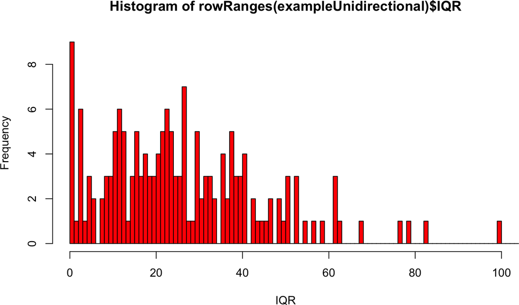

```r
hist(rowRanges(exampleUnidirectional)$IQR, breaks = max(rowRanges(exampleUnidirectional)$IQR),
    xlim = c(0, 100), xlab = "IQR", col = "red")
```

`shapeEntropy` works in the same way. Advanced users may implement their own shape statistic by writing a new function:

```r
# Write a function that quantifies the lean of a TSS
shapeLean <- function(x, direction) {
    # Coerce to normal vector
    x <- as.vector(x)

    # Find highest position:
    i <- which.max(x)

    # Calculate sum
    i_total <- sum(x)

    # Calculate lean fraction
    if (direction == "right") {
        i_lean <- sum(x[i:length(x)])
    } else if (direction == "left") {
        i_lean <- sum(x[1:i])
    } else {
        stop("direction must be left or right!")
    }

    # Calculate lean
    o <- i_lean/i_total

    # Return
    o
}

# Calculate lean statistics, additional arguments can be passed to calcShape
# via '...'
exampleUnidirectional <- calcShape(exampleUnidirectional, exampleCTSSs, outputColumn = "leanRight",
    shapeFunction = shapeLean, direction = "right")
```

```
#> Splitting coverage by strand...
#> Applying function to each TC...
#> Assembling output...
```

```r
exampleUnidirectional <- calcShape(exampleUnidirectional, exampleCTSSs, outputColumn = "leanLeft",
    shapeFunction = shapeLean, direction = "left")
```

```
#> Splitting coverage by strand...
#> Applying function to each TC...
#> Assembling output...
```

## 6.3 Gene level analysis

CAGE can detect TSSs and enhancers completely independent of existing gene models. However many databases of functional annotation, such as GO and KEGG terms, are only available at gene level. One might need to compare CAGE data to existing RNA-Seq or Microarray data only available at the gene level.

Another typical analysis is to look at Differential TSS Usage (DTU), sometimes refered to as alternative TSSs or promoter switches. Here the aim is to identify if genes utilize different TSSs under different conditions, independently of whether the overall gene expression changes.

### 6.3.1 Annotation with gene models

In a similar fashion to transcript annotation described above Annotation with transcript models, gene models are obtained via `TxDb` objects:

```r
# Load example TSS
data(exampleUnidirectional)

# Keep only TCs expressed at more than 1 TPM in more than 2 samples:
exampleUnidirectional <- calcTPM(exampleUnidirectional, totalTags = "totalTags")
```

```
#> Using supplied library sizes...
#> Calculating TPM...
```

```r
exampleUnidirectional <- subsetBySupport(exampleUnidirectional, inputAssay = "TPM",
    unexpressed = 1, minSamples = 2)
```

```
#> Calculating support...
#> Subsetting...
#> Removed 17141 out of 17313 regions (99%)
```

```r
# Use the Bioconductor mm9 UCSC TxXb
library(TxDb.Mmusculus.UCSC.mm9.knownGene)
txdb <- TxDb.Mmusculus.UCSC.mm9.knownGene
```

The `assignGeneID` function annotate ranges with gene IDs:

```r
exampleUnidirectional <- assignGeneID(exampleUnidirectional, geneModels = txdb,
    outputColumn = "geneID")
```

```
#> Extracting genes...
#> Overlapping while taking distance to nearest TSS into account...
#> Finding hierachical overlaps...
#> ### Overlap Summary: ###
#> Features overlapping genes: 88.37 %
#> Number of unique genes: 89
```

TSSs not overlappping any genes receive NA, and in the (usually rare) case of a TC overlapping multiple genes, the gene with the closest annotated TSS is chosen:

What type of gene ID is returned of course depends on the source of the `TxDb` object supplied. In this case, it is Entrez IDs, the most commonly used ID system in Bioconductor. Entrez IDs can be used to find the corresponding gene symbols using an `OrgDb` object:

```r
# Use Bioconductor OrgDb package
library(org.Mm.eg.db)
```

```r
odb <- org.Mm.eg.db

# Match IDs to symbols
symbols <- mapIds(odb, keys = rowRanges(exampleUnidirectional)$geneID, keytype = "ENTREZID",
    column = "SYMBOL")
# Add to object
rowRanges(exampleUnidirectional)$symbol <- as.character(symbols)
```

For most gene-level operations in `CAGEfightR` NAs (TCs not overlapping genes) are simply removed. If you wish to keep these TCs, you can relabel them as “Novel” genes via the `assignMissingID` function:

```r
exampleUnidirectional <- assignMissingID(exampleUnidirectional, outputColumn = "symbol")
```

```
#> Assigned 2 missing IDs
```

### 6.3.2 Quantify expression at gene-level

Once TCs have been assigned to genes, TC expression can be summed up within genes to obtain a gene-level expression matrix via the `quantifyGenes` function:

```r
genelevel <- quantifyGenes(exampleUnidirectional, genes = "geneID", inputAssay = "counts")
```

This returns a `RangedSummarizedExperiment` with the same number of rows as genes. The ranges are returned as a `GRangesList` of the individual TSSs making up the expression of the genes:

```r
rowRanges(genelevel)
```

```
#> GRangesList object of length 88:
#> $100217439
#> GRanges object with 5 ranges and 5 metadata columns:
#>                             seqnames               ranges strand |     score
#>                                <Rle>            <IRanges>  <Rle> | <numeric>
#>   chr19:53899602-53899622;-    chr19 [53899602, 53899622]      - |  5.201151
#>   chr19:55817615-55817733;-    chr19 [55817615, 55817733]      - |  7.014526
#>   chr19:56738135-56738213;-    chr19 [56738135, 56738213]      - | 11.955951
#>   chr19:57432920-57432984;-    chr19 [57432920, 57432984]      - |  7.027865
#>   chr19:60842388-60842675;-    chr19 [60842388, 60842675]      - | 14.661015
#>                                            thick   support      geneID
#>                                        <IRanges> <integer> <character>
#>   chr19:53899602-53899622;- [53899605, 53899605]         3   100217439
#>   chr19:55817615-55817733;- [55817695, 55817695]         3   100217439
#>   chr19:56738135-56738213;- [56738161, 56738161]         3   100217439
#>   chr19:57432920-57432984;- [57432963, 57432963]         3   100217439
#>   chr19:60842388-60842675;- [60842645, 60842645]         3   100217439
#>                                  symbol
#>                             <character>
#>   chr19:53899602-53899622;-     Snora19
#>   chr19:55817615-55817733;-     Snora19
#>   chr19:56738135-56738213;-     Snora19
#>   chr19:57432920-57432984;-     Snora19
#>   chr19:60842388-60842675;-     Snora19
#>
#> $100217466
#> GRanges object with 1 range and 5 metadata columns:
#>                             seqnames               ranges strand |    score
#>   chr18:74938323-74938515;-    chr18 [74938323, 74938515]      - | 243.8867
#>                                            thick support    geneID   symbol
#>   chr18:74938323-74938515;- [74938434, 74938434]       3 100217466 Scarna17
#>
#> $100502841
#> GRanges object with 1 range and 5 metadata columns:
#>                             seqnames               ranges strand |    score
#>   chr18:78135139-78135265;+    chr18 [78135139, 78135265]      + | 101.8611
#>                                            thick support    geneID symbol
#>   chr18:78135139-78135265;+ [78135206, 78135206]       3 100502841   Epg5
#>
#> ...
#> <85 more elements>
#> -------
#> seqinfo: 35 sequences (1 circular) from mm9 genome
```

Gene-level values are accesible via the `rowData` function:

```r
rowData(genelevel)
```

```
#> DataFrame with 88 rows and 1 column
#>     nClusters
#>     <integer>
#> 1           5
#> 2           1
#> 3           1
#> 4           1
#> 5           2
#> ...       ...
#> 84          1
#> 85          2
#> 86          1
#> 87          1
#> 88          1
```

The gene-level expression matrix can now be supplied to many other Bioconductor packages, including DESeq2, edgeR, limma, etc.

### 6.3.3 Filtering clusters based on gene composition

When looking at Differential TSS Usage (DTU) we are interested in changes in the contribution of individual TCs to overall gene expression. Since CAGE can detect even very lowly expressed TSSs, it is common to see TSSs making up only a very small fraction of the total gene expression. Removing these TSSs can improve power and clarity of downstream analyses.

`CAGEfightR` can calculate the *composition* value of intragenic TCs, defined as the number of samples expressing a TC at more than a certain fraction of total gene expression. This is implemented in the `calcComposition` function:

```r
# Remove TSSs not belonging to any genes
intragenicTSSs <- subset(exampleUnidirectional, !is.na(geneID))

# Calculate composition: The number of samples expressing TSSs above 10% of
# the total gene expression.
intragenicTSSs <- calcComposition(intragenicTSSs, outputColumn = "composition",
    unexpressed = 0.1, genes = "geneID")

# Overview of composition values:
table(rowRanges(intragenicTSSs)$composition)
```

```
#>
#>   0   1   2   3
#>  22   8   6 116
```

We can see that many TSSs makes up less than 10% in all samples. These can be removed with `subset`:

```r
# Remove TSSs with a composition score less than 3
intragenicTSSs <- subset(intragenicTSSs, composition > 2)
```

The `subsetByComposition` function wraps the common task of calling `calcComposition` and `subset`. After filtering, the resulting expression matrix can be used with popular Bioconductor packages for DTU calling, such as DEXSeq, DRIMSeq, edgeR, limma, etc.

## 6.4 Plotting CAGE data in a genome browser

[Zenbu](http://fantom.gsc.riken.jp/zenbu/) is an excellent online genome browser for visualizing CAGE data in relation to annotation in an interative manner. For producing figures (or possibly a very large number of figures) of specific genomic regions, it can be useful to use R to generate genome browser-like plots.

`CAGEfightR` can produce genome browser plots via the popular and extensive *Gviz* package. `CAGEfightR` provides functions for generating genome browser tracks for both CTSSs and clusters. For general generation and customization of GViz plots we refer to the extensive *Gviz* manual. Below we include some basic examples of visualizing CAGE data.

First we load use the built-in datasets:

```r
library(Gviz)
data("exampleCTSSs")
data("exampleUnidirectional")
data("exampleBidirectional")
```

First we make a track of pooled CTSSs:

```r
# Calculate pooled CTSSs
exampleCTSSs <- calcTPM(exampleCTSSs, totalTags = "totalTags")
```

```
#> Using supplied library sizes...
#> Calculating TPM...
```

```r
exampleCTSSs <- calcPooled(exampleCTSSs)
# Built the track
pooled_track <- trackCTSS(exampleCTSSs, name = "CTSSs")
```

```
#> Splitting pooled signal by strand...
#> Preparing track...
```

The returned object is a `DataTrack`, which we can plot a specific genomic region of:

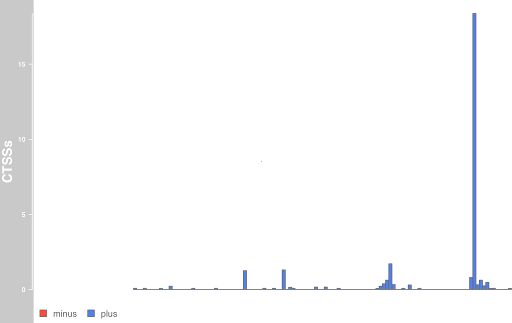

```r
# Plot the main TSS of the myob gene
plotTracks(pooled_track, from = 74601950, to = 74602100, chromosome = "chr18")
```

Secondly, we make a track of clusters: This function can handle both TSSs and enhancers, so we first merge them into a single object:

```r
# Remove columns
exampleUnidirectional$totalTags <- NULL
exampleBidirectional$totalTags <- NULL

# Combine TSSs and enhancers, discarding TSSs if they overlap enhancers
CAGEclusters <- combineClusters(object1 = exampleUnidirectional, object2 = exampleBidirectional,
    removeIfOverlapping = "object1")
```

```
#> Removing overlapping features from object1: 1049
#> Keeping assays: counts
#> Keeping columns: score, thick
#> Merging metadata...
#> Stacking and re-sorting...
```

```r
# Only keep features with more than 0 counts in more than 2 samples
CAGEclusters <- subsetBySupport(CAGEclusters, inputAssay = "counts", unexpressed = 0,
    minSamples = 2)
```

```
#> Calculating support...
#> Subsetting...
#> Removed 15198 out of 16654 regions (91.3%)
```

```r
# Built track
cluster_track <- trackClusters(CAGEclusters, name = "Clusters", col = NA)
```

```
#> Setting thick and thin features...
#> Merging and sorting...
#> Preparing track...
```

The returned object is a `GeneRegionTrack`, which we can plot the same genomic region of:

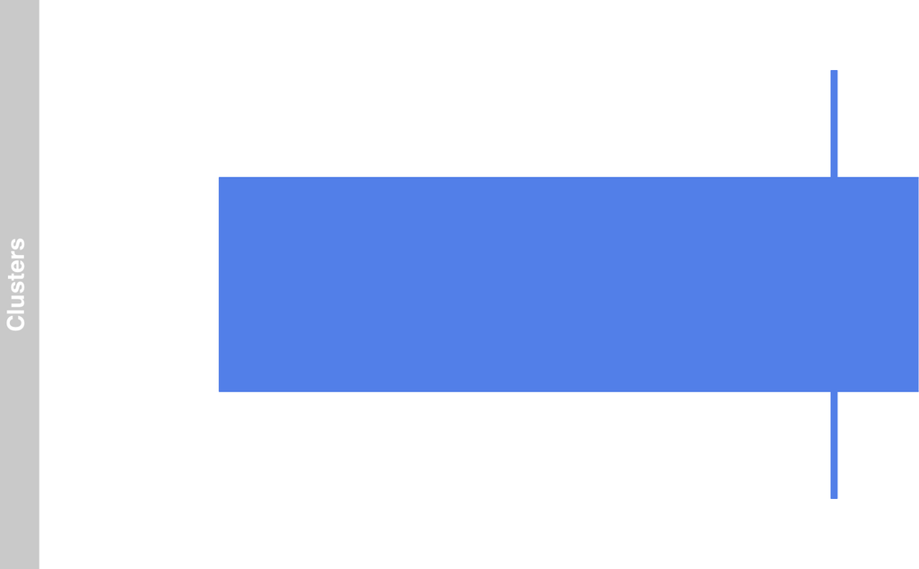

```r
# Plot the main TSS of the myob gene
plotTracks(cluster_track, from = 74601950, to = 74602100, chromosome = "chr18")
```

Of course, we want to combine several different tracks into a single overview. There is multiple ways of doing this, and the code below is just one such way:

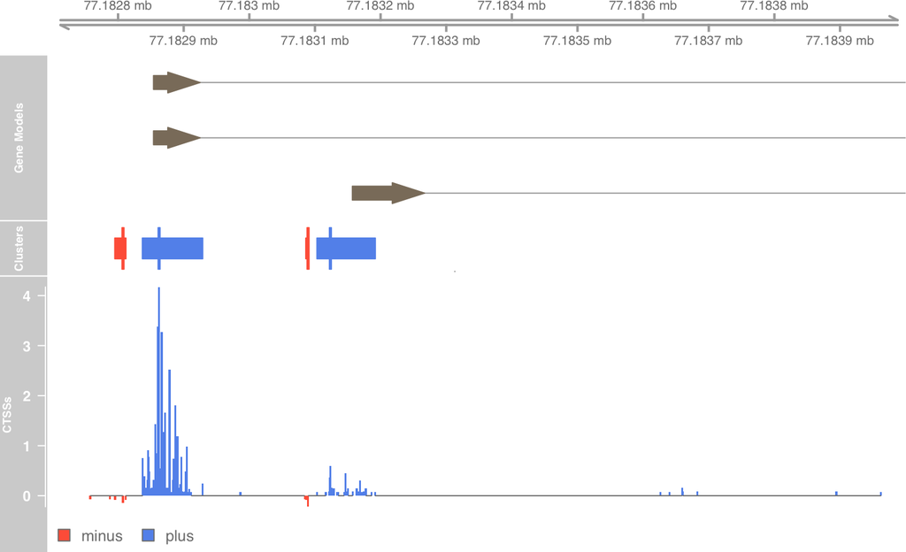

```r
# Genome axis tracks
axis_track <- GenomeAxisTrack()

# Transcript model track
library(TxDb.Mmusculus.UCSC.mm9.knownGene)
txdb <- TxDb.Mmusculus.UCSC.mm9.knownGene
tx_track <- GeneRegionTrack(txdb, name = "Gene Models", col = NA, fill = "bisque4",
    shape = "arrow")

# Merge all tracks
all_tracks <- list(axis_track, tx_track, cluster_track, pooled_track)

# Plot the Hdhd2 gene
plotTracks(all_tracks, from = 77182700, to = 77184000, chromosome = "chr18")
```

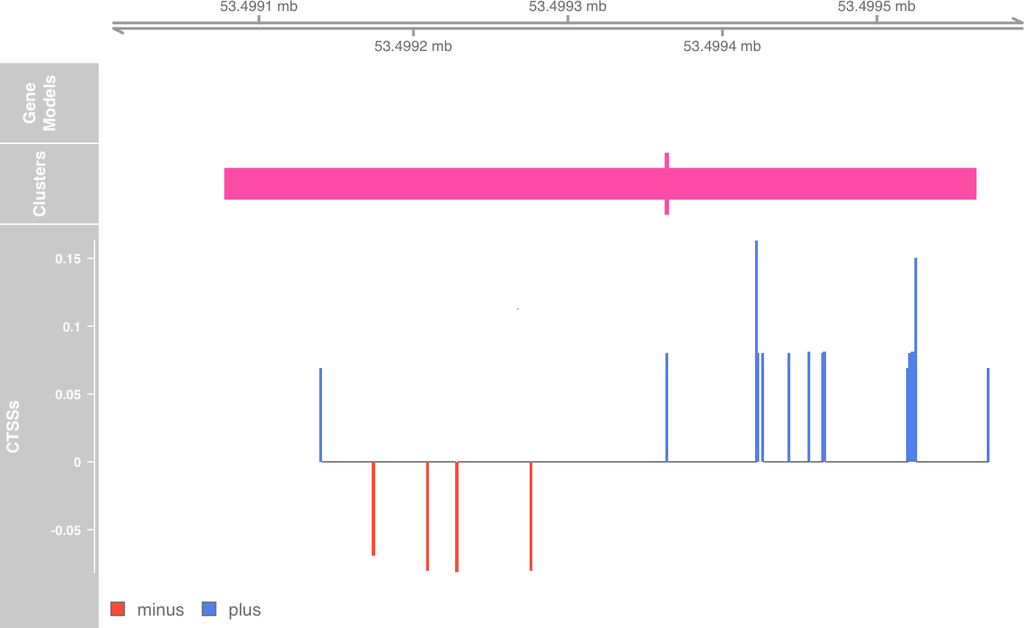

```r
# Plot an intergenic enhancer
plotTracks(all_tracks, from = 53499000, to = 53499600, chromosome = "chr19")
```

## 6.5 Parallel execution

Currently, two functions can utilize multiple cores for computation, `quantifyCTSSs` and `tuneTagClustering`. The central one is `quantifyCTSSs`, which is usually the slowest and most memory consuming step of a `CAGEfightR` analysis. `quantifyCTSSs` automatically uses the default backend registered with the *BiocParallel* package. This can be changed in the following way:

```r
library(BiocParallel)

# Setup for parallel execustion with 3 threads:
register(MulticoreParam(workers = 3))

# Disable parallel execution
register(SerialParam())
```